# EXDATA-030 PLOT1 Handbook

zafbrb

Friday, July 10, 2015

To preview this on Github goto this address **http://htmlpreview.github.io/** and put in the web address of this html file on github.

Using data from the **UC Irvine Machine Learning Repository**, we will produce 4 plots showing how household energy usage varies over a 2 day period

# Codebook

The data has been extracted from the **UC Irvine Machine Learning Repository**

```
The file is https://d396qusza40orc.cloudfront.net/exdata%2Fdata%2Fhousehold_power_consumption.zip
1. Date: Date in format dd/mm/yyyy
2. Time: time in format hh:mm:ss
3. Global_active_power: household global minute-averaged active power (in kilowatt)
4. Global_reactive_power: household global minute-averaged reactive power (in kilowatt)
5. Voltage: minute-averaged voltage (in volt)
6. Global_intensity: household global minute-averaged current intensity (in ampere)
7. Sub_metering_1: energy sub-metering No. 1 (in watt-hour of active energy). It corresponds to the kitchen, containing mainly a dishwasher, an oven and a microwave (hot plates are not electric but gas powered).
8. Sub_metering_2: energy sub-metering No. 2 (in watt-hour of active energy). It corresponds to the laundry room, containing a washing-machine, a tumble-drier, a refrigerator and a light.
9. Sub_metering_3: energy sub-metering No. 3 (in watt-hour of active energy). It corresponds to an electric water-heater and an air-conditioner.
```

# Data Prep Code

This portion of the code basically preps the data for exploratory plotting. The Plotx.R scripts have slightly more advanced code to check to see if the file exists and if not, download it from the internet

```
fileURL <- "household_power_consumption.txt"
#lets read in the large file, remove NA's
energy1 <- read.table(fileURL, sep = ";", header = TRUE, na.strings= "?", stringsAsFactors = FALSE)
#Set the date column to the correct class
energy1$Date <- as.Date(energy1$Date, "%d/%m/%Y")
# Get subset of larger data frame for the days in question
energy2 <- subset(energy1, Date >= "2007-02-01" & Date <= "2007-02-02")
#Clean up
rm(energy1)
# Create DateTimestamp column we can use for plotting
dt <- paste(energy2$Date, energy2$Time)
dt2 <- strptime(dt, "%Y-%m-%d %H:%M:%S", "GMT")
#Show the shape of the dataframe
str(energy2)
```

```
## 'data.frame':    2880 obs. of  9 variables:
##  $ Date                 : Date, format: "2007-02-01" "2007-02-01" ...
##  $ Time                 : chr  "00:00:00" "00:01:00" "00:02:00" "00:03:00" ...
##  $ Global_active_power  : num  0.326 0.326 0.324 0.324 0.322 0.32 0.32 0.32 0.32 0.236 ...
##  $ Global_reactive_power: num  0.128 0.13 0.132 0.134 0.13 0.126 0.126 0.126 0.128 0 ...
##  $ Voltage              : num  243 243 244 244 243 ...
##  $ Global_intensity     : num  1.4 1.4 1.4 1.4 1.4 1.4 1.4 1.4 1.4 1 ...
##  $ Sub_metering_1       : num  0 0 0 0 0 0 0 0 0 0 ...
##  $ Sub_metering_2       : num  0 0 0 0 0 0 0 0 0 0 ...
##  $ Sub_metering_3       : num  0 0 0 0 0 0 0 0 0 0 ...
```

## Plot1

Code for plotting is shown below

```
par(mfrow=c(1,1))
with(energy2, hist(Global_active_power, col="red", main = "Global Active Power"))
```

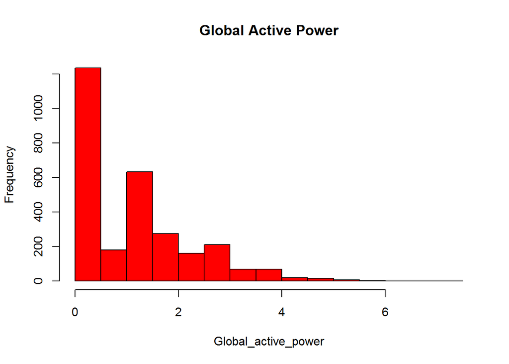

## Plot2

Code for plotting is shown below. This plot requires the DateTime stamp column of data (dt2). the strptime() will create a data + time stamp

```
# Need to create a Date/Timestamp column for this plot
    dt <- paste(energy2$Date, energy2$Time)
    dt2 <- strptime(dt, "%Y-%m-%d %H:%M:%S", "GMT")
```

You will notice that I did not put this back to the data frame(as a extra column)…normally that would be better practise.

```
par(mfrow=c(1,1))
with(energy2, plot(dt2, Global_active_power, type="l", xlab = "Datetime",
                       ylab = "Global Active Power (kilowatts)"))
```

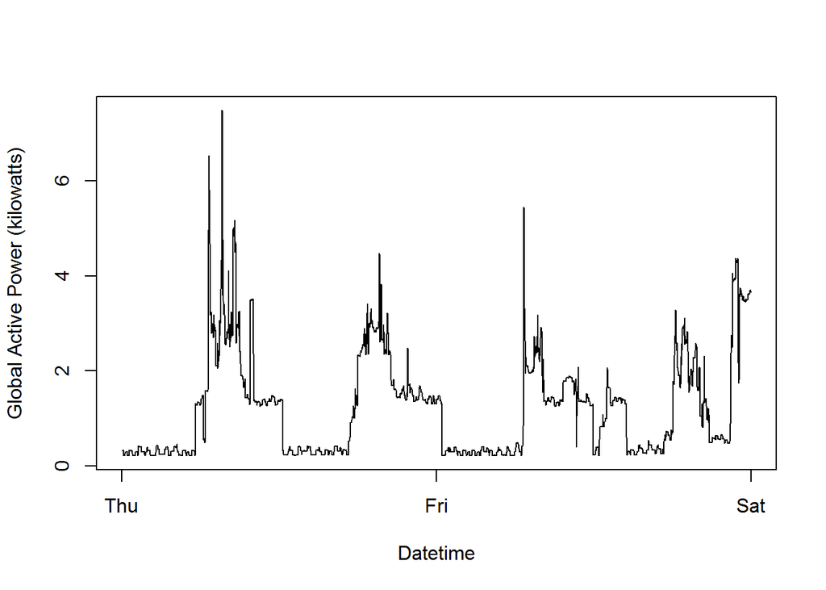

## Plot3

Code for plotting is shown below. Notice we create a legend for this plot. Trying to save the screen plot and copying it to the PNG file always seemed to truncate the legend text. I found that writing the plot directly to a PNG file using PNG(file=“name”, width=480 , height=480) gave the correct result

```
par(mfrow=c(1,1))
plot(dt2, energy2$Sub_metering_1, type="n", ylab="Energy sub metering", xlab="")
lines(dt2, energy2$Sub_metering_1, type="l", col="black")
lines(dt2, energy2$Sub_metering_2, type="l", col="red")
lines(dt2, energy2$Sub_metering_3, type="l", col="blue")
legend("topright","", c("Sub_metering_1", "Sub_metering_2", "Sub_metering_3"),
       lwd=1, col=c("black", "red", "blue"))
```

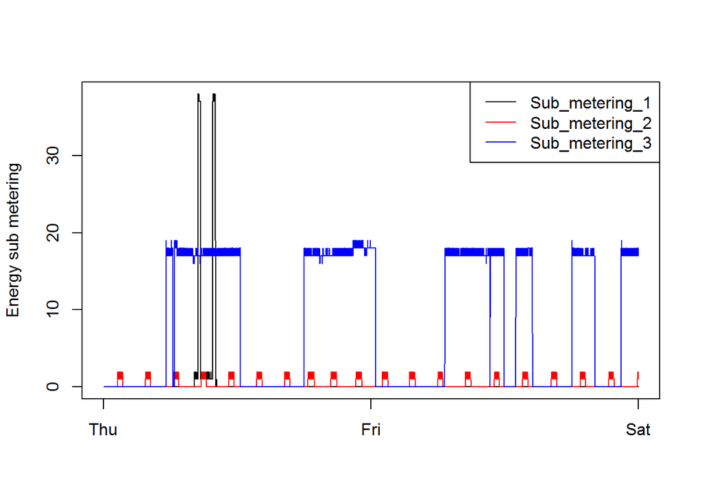

## Plot4

Code for plotting is shown below. In this case I had to adjust the margins for the plots and the outer margin. We also put a plot title in - just for fun

Again the better approach was to write this directly to the PNG device.

```
par(mfrow = c(2,2), mar=c(4, 4, 2, 1), oma = c(0, 0, 2, 0))
    with(energy2, {
        plot(dt2, Global_active_power, type="l", xlab = "Datetime",
             ylab = "Global Active Power")
        plot(dt2, Voltage, type="l", xlab = "Datetime", ylab="Voltage")
        plot(dt2, energy2$Sub_metering_1, type="n",
             ylab="Energy sub metering", xlab="Datetime")
        lines(dt2, energy2$Sub_metering_1, type="l", col="black")
        lines(dt2, energy2$Sub_metering_2, type="l", col="red")
        lines(dt2, energy2$Sub_metering_3, type="l", col="blue")
        legend("topright","", c("Sub_metring_1", "Sub_metering_2", "Sub_metering_3"),
               lwd=1, col=c("black", "red", "blue"))
        plot(dt2, Global_reactive_power, type="l", xlab="Datetime", ylab = "Global Reactive Power")
        mtext("Exploratory Data Analysis - Project 1 Plotting", outer = TRUE)
    })
```

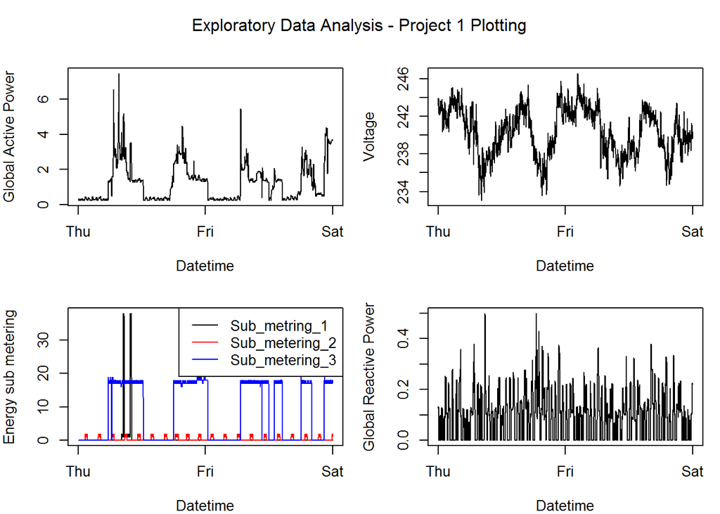

## Improvements

Its good to think about improvements

1. Add the DateTime stamp back to the energy2 dataframe as an extra column
2. Encapsulate the data reading and subsetting code into a function so it can be re-used
3. Save the subsetted file to local storage and use that to read in for each plot

## Test Harness

The R script file **test_plot.R** will run all PLOT files. Assumes all the PLOTx.R files are in the working directory

Output example from test harness run

```
> plot_test()
*** Plot1 starting ***
[Plot1] Checking if data is already present in local directory...
 [Plot1] Data not present - downloading from Internet...hold on
trying URL 'https://d396qusza40orc.cloudfront.net/exdata%2Fdata%2Fhousehold_power_consumption.zip'
Content type 'application/zip' length 20640916 bytes (19.7 Mb)
opened URL
downloaded 19.7 Mb

[Plot1] Unpacked date source files into  G:/Learning/Data Scientist/DataExpWeek1/Data Explore Week 1
[Plot1] Reading large dataset - this may take a while...Done!
[Plot1] Plotting...
[Plot1] Plot written to plot1.png in local directory G:/Learning/Data Scientist/DataExpWeek1/Data Explore Week 1
*** Plot1 completed ***
*** Plot2 starting ***
[Plot2] Checking if data is already present in local directory...Data present - using local content
[Plot2] Reading large dataset - this may take a while...Done!
[Plot2] Plotting...
[Plot2] Plot written to Plot2.png in local directory G:/Learning/Data Scientist/DataExpWeek1/Data Explore Week 1
*** Plot2 completed ***
*** Plot3 starting ***
[Plot3] Checking if data is already present in local directory...Data present - using local content
[Plot3] Reading large dataset - this may take a while...Done!
[Plot3] Plotting...
[Plot3] Plot written to Plot3.png in local directory G:/Learning/Data Scientist/DataExpWeek1/Data Explore Week 1
*** Plot3 completed ***
*** Plot4 starting ***
[Plot4] Checking if data is already present in local directory...Data present - using local content
[Plot4] Reading large dataset - this may take a while...Done!
[Plot4] Plot written to Plot4.png in local directory G:/Learning/Data Scientist/DataExpWeek1/Data Explore Week 1
*** Plot4 completed ***
```